# Module 5 Sharks

Team 1 Tech Trio

2024-10-22

# Introduction

Habitat shapes species’ morphology, as organisms adapt to different environments. Morphospace, representing the range of shapes species can occupy, helps visualize these differences. Studies show that species in distinct habitats, like benthic vs. pelagic, exhibit significant morphological variation due to ecological pressures (Compagno (1984) Grogan, Lund, and Greenfest-Allen (2012) Sternes and Shimada (2020)). Furthermore, the rate of morphological evolution may vary between habitats, with some fostering faster evolutionary changes (Stein et al. (2018)).

This study addresses two questions: (1) Does habitat influence morphospace occupation? (2) Do species from different habitats evolve at different rates? To answer this, we use PCA of Procrustes-aligned landmark data to compare morphospace and assess morphological disparity and evolutionary rates across habitats. This project aims to provide insight into how ecological niches affect morphology’s evolution in the selected shark species.

# Methods

To determine whether habitat affects morphospace occupation and morphological evolution rates, we analyzed landmark data from seven species. The body shapes of multiple shark species were digitized using landmark-based geometric morphometrics, with the 14 points digitized as such.

[figure not shown]

14 Landmarks Digitized on Each Shark Specimin.

A dataset was established using all digitized specimens, using Procrustes alignment to remove differences in size, rotation, and position, standardizing the shapes for comparison (Sternes and Shimada (2020)). A principal components analysis (PCA) was then conducted to visualize how species from different habitats occupy morphospace, focusing on the first two principal components (Grogan, Lund, and Greenfest-Allen (2012)).

To assess morphological disparity within habitats, we used the morphol.disparity function to quantify shape variation (Thomson and Simanek (1977)). We also applied the compare.evol.rates function across 500 phylogenetic trees to calculate evolutionary rates, leveraging parallel computing for efficiency. Finally, a two-sided t-test compared the evolutionary rates between benthic and pelagic habitats to test for significant differences.

# Results

Procrustes Alignment of Digitized Specimens Visualization

```
## ──────────────────────────────────────────────────────── Delimiter: "," dbl
## (14): ...1, Area, Mean, Mode, X, Y, XM, YM, Perim., Circ., Slice, AR, Ro...
```

[output not shown]

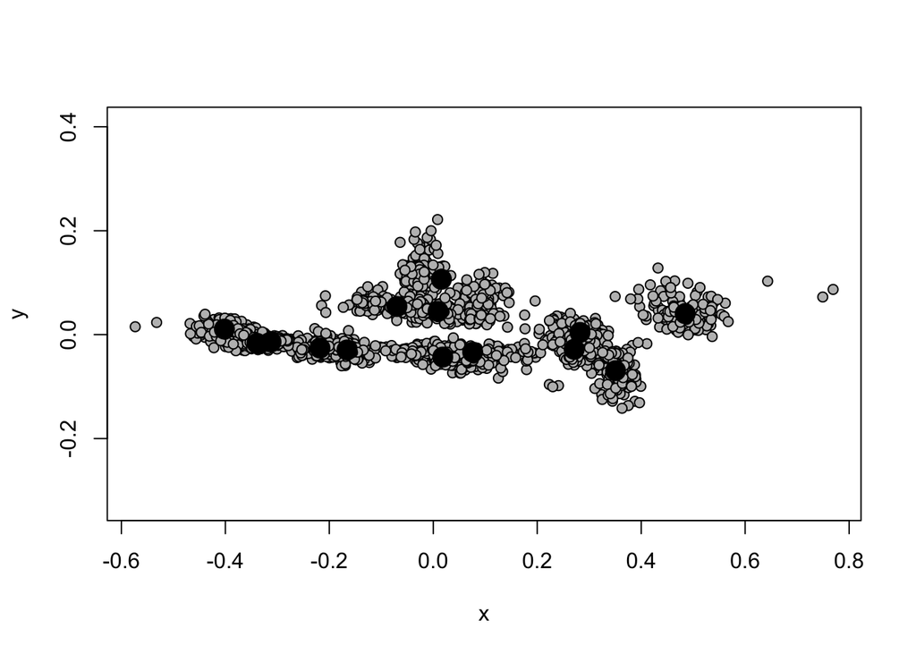

Procrustes Alignment of Shark Morphological Shape Coordinates by Species.

## Morphospace Based on PCA

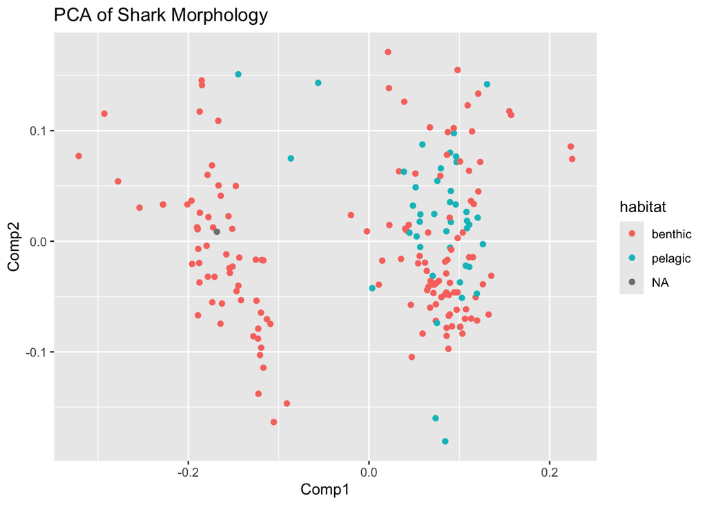

Principle Component Analysis of Shark Morphology Based on Habitat, Using 2 Principle Components.

# Morphological Disparity

```
##
## Call:
## morphol.disparity(f1 = coords ~ 1, groups = ~habitat, iter = 10000,
##     data = gdf, print.progress = FALSE)
##
##
##
## Randomized Residual Permutation Procedure Used
## 10001 Permutations
##
## Procrustes variances for defined groups
##    benthic         NA    pelagic
## 0.02950302 0.03244622 0.02504977
##
##
## Pairwise absolute differences between variances
##             benthic          NA     pelagic
## benthic 0.000000000 0.002943198 0.004453246
## NA      0.002943198 0.000000000 0.007396444
## pelagic 0.004453246 0.007396444 0.000000000
##
##
## P-Values
##           benthic        NA   pelagic
## benthic 1.0000000 0.8759124 0.2679732
## NA      0.8759124 1.0000000 0.6607339
## pelagic 0.2679732 0.6607339 1.0000000
```

# Morphological Evolution

Based on the visual aid and the T-test performed on the data, the rate of morphological evolution is significantly different between benthic and pelagic habitats. Benthic sharks evolve at a significantly higher rate than pelagic sharks, with a highly significant p-value indicating that this difference is unlikely to be due to random chance.

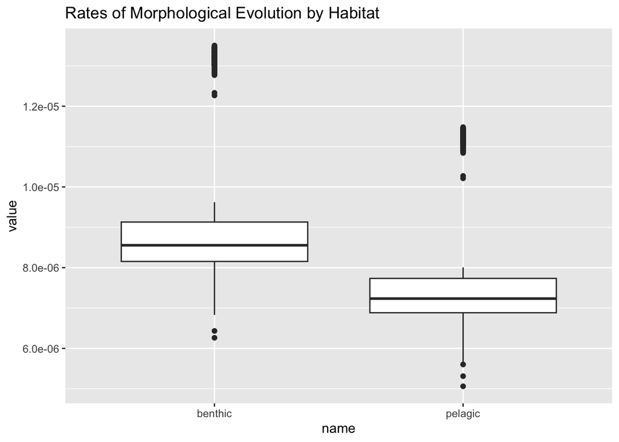

Rates of Morphological Evolution in Shark Morphology by Habitat.

```
##
##  Welch Two Sample t-test
##
## data:  er$benthic and er$pelagic
## t = 11.986, df = 976.55, p-value < 2.2e-16
## alternative hypothesis: true difference in means is not equal to 0
## 95 percent confidence interval:
##  1.211534e-06 1.685938e-06
## sample estimates:
##    mean of x    mean of y
## 9.351523e-06 7.902787e-06
```

# Discussion

The results of this study highlight a significant difference in the rate of morphological evolution between benthic and pelagic shark species. Our evolutionary rate analyses, performed across 500 phylogenetic trees, revealed that benthic sharks exhibit faster morphological changes compared to pelagic species, supported by a highly significant p-value. This suggests that benthic environments may impose stronger selective pressures or allow for greater morphological diversification, potentially due to the varied substrates and complex structures found in benthic habitats. These findings align with a previous study conducted by (Irschick et al. (2017)), which analyzed body and fin shape among eight groups of Atlantic sharks. They concluded that the most significant variable distinguishing species was variation in body length, which is mainly affected by variation in diet and habitat. Our analysis was on a broader scale, but both studies indicate that habitat can drive distinct evolutionary dynamics, reinforcing the hypothesis that environmental context influences evolutionary rates.

# Author Contributions

The team communicated through messaging. Jax assigned the images, and analyzed the first 8 images, Mee examined the next 7, and John reviewed the final 7. Questions and answers were done equally by all three members throughout the course of the Module. Jax worked heavily on the coding piece of the project, while John and Mee both contributed to the writing section heavily. John found a new source for us to use for the project. Jax created the master document and repository.

# References

Compagno, Leonard JV. 1984. *Sharks of the World. An Annotated and Illustrated Catalogue of Sharks Species Known to Date*. Food & Agricueelture Org.

Grogan, Eileen D, Richard Lund, and Emily Greenfest-Allen. 2012. “The Origin and Relationships of Early Chondrichthyans.” In *Biology of Sharks and Their Relatives*, 2:3–29.

Irschick, Duncan J, Amy Fu, George Lauder, Cheryl Wilga, Chi-Yun Kuo, and Neil Hammerschlag. 2017. “A comparative morphological analysis of body and fin shape for eight shark species.” *Biological Journal of the Linnean Society* 122 (3): 589–604. https://doi.org/10.1093/biolinnean/blx088.

Stein, R William, Christopher G Mull, Tyler S Kuhn, Neil C Aschliman, Lindsay NK Davidson, Jeffrey B Joy, Gordon J Smith, Nicholas K Dulvy, and Arne O Mooers. 2018. “Global Priorities for Conserving the Evolutionary History of Sharks, Rays and Chimaeras.” *Nature Ecology & Evolution* 2 (2): 288–98.

Sternes, Phillip C, and Kenshu Shimada. 2020. “Body Forms in Sharks (Chondrichthyes: Elasmobranchii) and Their Functional, Ecological, and Evolutionary Implications.” *Zoology* 140: 125799.

Thomson, Keith Stewart, and Dan E Simanek. 1977. “Body Form and Locomotion in Sharks.” *American Zoologist* 17 (2): 343–54.